# Globalization and Climate Change: Food Trade

Krista Waugh and Andrew Lind

12/10/2018

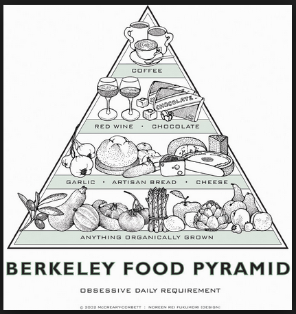

Berkeley Food Pyramid

```r
library(readr)
library(ggplot2)
library(dplyr)
library(tidyverse)
library(httr)
library(jsonlite)
library(tidyr)
```

# Introduction and Explanation

In this report, we will examine the effects globalization in relation to food on the climate. Taking inspiration from this cute image of the “Berkeley Food Pyramid”, found in Peet’s Coffee on 4th street, we will examine what it means for cities worldwide to adopt foreign foods as their own. In this example, we can see some products like wine, cheese, and produce, especially garlic, are produced in California and not shipped very far to come to Berkeley. However, other items like coffee and chocolate have to be shipped from countries mainly in the global south, like Colombia, Ethiopia, Vietnam, and Brazil.

Cheap, widely available oil makes it easier to ship all goods, including food, all over the world, rather than engage in locally grown and produced goods. Under longstanding trade agreements, fuel for international freight carried by sea and air is not taxed. However, this convenience comes at a cost to the environment. We are going to examine the trends in US food imports, trends in carbon emissions in the US, as well as global atmospheric CO2 concetrations during the same period.

While there are many contributing factors to climate change, the rise of global CO2 emissions cannot be attributed solely to importing and exporting food. This analysis will hopefully highlight the global interconnectedness in all facets of trade and the way the current world economy drives climate change.

The foods we studied were selected to mirror the “Berkeley Food Pyramid” shown above, to depict this trend in a way that challenges the idea that coffee and chocolate are part of Berkeley’s food culture, and to demonstrate that cities worldwide are accustomed to making certain foods part of their culture without mind to the damage to the environment that this practice causes.

### Information about the US Food Import Dataset, from the data.gov website

> U.S. consumers demand variety, quality, and convenience in the foods they consume. As Americans have become wealthier and more ethnically diverse, the American food basket reflects a growing share of tropical products, spices, and imported gourmet products. Seasonal and climatic factors drive U.S. imports of popular types of fruits and vegetables and tropical products, such as cocoa and coffee. In addition, a growing share of U.S. imports can be attributed to intra-industry trade, whereby agricultural-processing industries based in the United States carry out certain processing steps offshore and import products at different levels of processing from their subsidiaries in foreign markets.

This data set provides import values of edible products (food and beverages) entering U.S. ports and their origin of shipment. Data are from the U.S. Department of Commerce, U.S. Census Bureau. Food and beverage import values are compiled by calendar year into food groups corresponding to major commodities or level of processing. At least 10 years of annual data are included, enabling users to track long-term growth patterns.

*Volumes of food below is represented in units of 1000 metric tons.*

```r
berkeley_pyramid_imports <- read_csv("Berkeley_Pyramid_Imports.csv")
berkeley_pyramid_imports
```

```
## # A tibble: 7 x 20
##   X1    `1999` `2000` `2001` `2002` `2003` `2004` `2005` `2006` `2007`
##   <chr>  <dbl>  <dbl>  <dbl>  <dbl>  <dbl>  <dbl>  <dbl>  <dbl>  <dbl>
## 1 Coff…  3604.  3442.  2401.  2455.  2872.  3144.  3771.  4195.  4791.
## 2 Vege…  3632.  3771.  4157.  4391.  5082.  5730.  6043.  6619.  7256.
## 3 Fruit  4764.  4629.  4665.  5068.  5558.  5962.  6874.  7707.  9217.
## 4 Coco…  1522.  1404.  1536.  1761.  2439.  2484.  2751.  2659.  2662.
## 5 Chee…   705.   685.   746.   788.   882.   982.  1007.  1029.  1107.
## 6 Wine   2169.  2186.  2227.  2646.  3240.  3382.  3722.  4112.  4591.
## 7 Wheat   421.   382.   435.   463.   349.   443.   418.   581.   849.
## # ... with 10 more variables: `2008` <dbl>, `2009` <dbl>, `2010` <dbl>,
## #   `2011` <dbl>, `2012` <dbl>, `2013` <dbl>, `2014` <dbl>, `2015` <dbl>,
## #   `2016` <dbl>, `2017` <dbl>
```

```r
product_imports <- read_csv("product_imports.csv")
product_imports
```

```
## # A tibble: 133 x 3
##     Year Product              Quantity
##    <int> <chr>                   <dbl>
##  1  1999 Coffe & tea & spices    3604.
##  2  2000 Coffe & tea & spices    3442.
##  3  2001 Coffe & tea & spices    2401.
##  4  2002 Coffe & tea & spices    2455.
##  5  2003 Coffe & tea & spices    2872.
##  6  2004 Coffe & tea & spices    3144.
##  7  2005 Coffe & tea & spices    3771.
##  8  2006 Coffe & tea & spices    4195.
##  9  2007 Coffe & tea & spices    4791.
## 10  2008 Coffe & tea & spices    5581.
## # ... with 123 more rows
```

```r
cheese <- filter(product_imports, Product == "Cheese")
vegetables <- filter(product_imports, Product == "Vegetables")
wine <- filter(product_imports, Product == "Wine")
fruit <- filter(product_imports, Product == "Fruit")
cocoa <- filter(product_imports, Product == "Cocoa & chocolate")
wheat <- filter(product_imports, Product == "Wheat")
coffee <- filter(product_imports, Product == "Coffe & tea & spices")
```

```r
food_graph <-
  ggplot(, aes(x = Year)) +
  geom_line(data = cheese, aes(y = Quantity, color = "cheese")) +
  geom_line(data = wine, aes(y = Quantity, color = "wine")) +
  geom_line(data = vegetables, aes(y = Quantity, color = "vegetables")) +
  geom_line(data = fruit, aes(y = Quantity, color = "fruit")) +
  geom_line(data = coffee, aes(y = Quantity, color = "coffee")) +
  geom_line(data = cocoa, aes(y = Quantity, color = "cocoa")) +
  geom_line(data = wheat, aes(y = Quantity, color = "wheat")) +
  scale_color_manual("",
                     breaks = c("cheese", "wine", "vegetables", "fruit", "coffee", "cocoa", "wheat"),
                     values = c("gold", "tan4", "black", "tomato", "forestgreen", "navajowhite", "maroon")) +
  theme_classic() +
  labs(x = "Year", y = "Quantity (1000 metric tons)", title = "Food Imports into the United States")
food_graph
```

[figure not shown]

*CO2 DATA*